# p8105_hw1_yz4183

Yuchen Zheng

9/24/2021

```r
library(tidyverse)
```

### Problem 1

This problem is intended to emphasize variable types and introduce coercion; some awareness of how R treats numeric, character, and factor variables is necessary for working with these data types in practice.

Create a data frame comprised of:

a random sample of size 10 from a standard Normal distribution a logical vector indicating whether elements of the sample are greater than 0 a character vector of length 10 a factor vector of length 10, with 3 different factor “levels”

```r
set.seed(123)

df = tibble(
  sample = rnorm(10),
  vec_logical = sample > 0,
  vec_char = c('A','B','C','D','E','F','G','H','I','J'),
  vec_factor = factor(c('1','2','3','1','2','3','1','2','3','1'))
)

df
```

```
## # A tibble: 10 × 4
##     sample vec_logical vec_char vec_factor
##      <dbl> <lgl>       <chr>    <fct>
##  1 -0.560  FALSE       A        1
##  2 -0.230  FALSE       B        2
##  3  1.56   TRUE        C        3
##  4  0.0705 TRUE        D        1
##  5  0.129  TRUE        E        2
##  6  1.72   TRUE        F        3
##  7  0.461  TRUE        G        1
##  8 -1.27   FALSE       H        2
##  9 -0.687  FALSE       I        3
## 10 -0.446  FALSE       J        1
```

Try to take the mean of each variable in your dataframe. What works and what doesn’t? Hint: to take the mean of a variable in a dataframe, you need to pull the variable out of the dataframe. Try loading the tidyverse and using the pull function.

```r
mean(pull(df, var = sample))
```

```
## [1] 0.07462564
```

```r
mean(pull(df, var = vec_logical))
```

```
## [1] 0.5
```

```r
mean(pull(df, var = vec_char))
```

```
## [1] NA
```

```r
mean(pull(df, var = vec_factor))
```

```
## [1] NA
```

We are able to take the mean of numeric and logical variable, but when taking the mean of logical variable, false is converted to 0 and true is converted to 1 and the mean of it is the sum of 0 and 1 over the length of the vector. We are not able to take the mean of character vector or the factor vector.

In some cases, you can explicitly convert variables from one type to another. Write a code chunk that applies the as.numeric function to the logical, character, and factor variables (please show this chunk but not the output). What happens, and why? Does this help explain what happens when you try to take the mean?

```r
as.numeric(pull(df, var = vec_logical))
as.numeric(pull(df, var = vec_char))
as.numeric(pull(df, var = vec_factor))
```

### Problem 2

```r
data("penguins", package = "palmerpenguins")
```

The penguins dataset has 8 columns and 344 rows. This dataset contains information about species, island, bill_length_mm, bill_depth_mm, flipper_length_mm, body_mass_g, sex, year for each penguin. The mean flipper length is 200.9152047 mm.

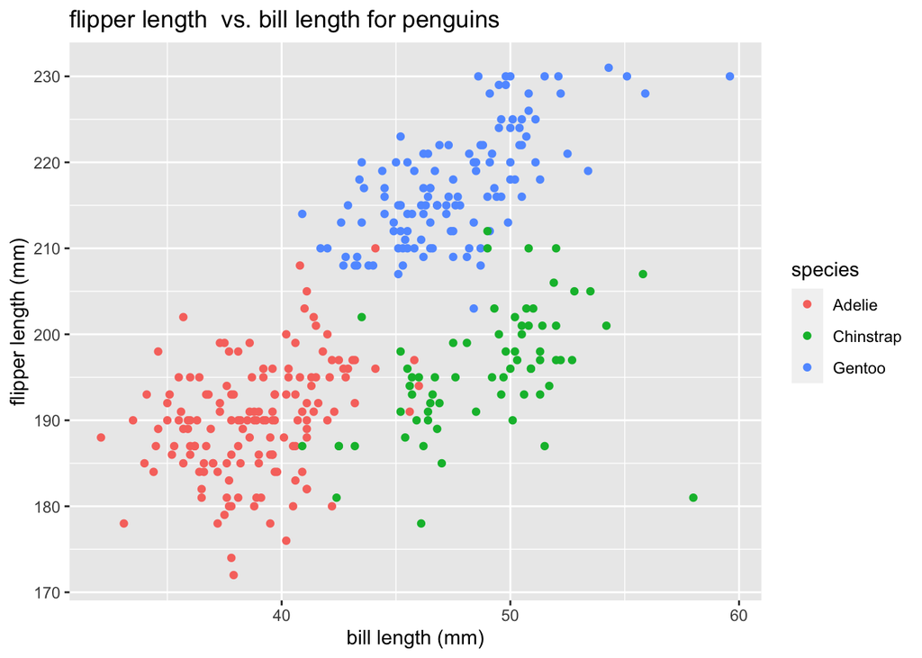

```r
ggplot(data = penguins, aes(x = bill_length_mm, y = flipper_length_mm, color = species)) + geom_point() +
labs(title = "flipper length  vs. bill length for penguins", x = "bill length (mm)", y = "flipper length (mm)")
```

```r
ggsave('penguins scatterplot.png')
```